# **SPSS Üzerinde Betimleyici İstatistiklerin Hesaplanması**

Belirtici istatistikler iki grupta incelenebilir. Öncelikle kullanılacak olan terimlerin neler olduğunu anlamamız gerekir.

## 1. **Yer (Eğilim) Ölçüleri (Measures of Location)**

### Ortalama neden gerekli?

- Elde edilen ham verinin frekans tablosu ya da sınıfandırılmış hale getirilmesi ya da düzenlenen verinin grafiksel yöntemlerle ifade edilmesi incelenen konuyla ilgili bir fikir verebilir ancak bu bilgiler kesin değerlendirmeler yapılması için yeterli değildir.
- Bu yüzden tüm seriyi tek bir sayıyla ifade eden, karşılaştırılabilir ölçütlere ihtiyaç duyulmuştur.
- Bu ölçütlere genel olarak merkezi eğilim ölçütleri denir.
- Ortalamalar en çok kullanılan ve en temel merkezi eğilim

ölçütlerindendir

En çok kullanılan ortalama türleri aşağıdaki gibidir..

***Aritmetik Ortalama (Mean, Average)***

- n değerin toplamının n’e (birim sayısına) bölünmesiyle bulunur.
- Çan eğrisi biçiminde simetrik dağılım gösteren verileri en iyi temsil eden merkezi eğilim ölçüsüdür.
- Analitik araştırmalarda en sık kullanılan istatistiktir.

***Geometrik Ortalama (Geometric Mean)***

- n birimin değerleri çarpımlarının n kökünün alınması ile bulunan bir istatistiktir.
- n değerin logaritmaları toplamının n’e bölünmesi ile bulunan logaritmik ortalamanın antilogaritması alınarak da hesaplanabilir.
- Aritmetik ya da geometrik olarak düzenli artan ya da azalan dizilerin merkezi eğilimini belirtmekte kullanılır.

### SPSS’de Betimleyici İstatistiklerin Hesaplanması

Bu örnekte kullanacağımız veri ***hs0.sav*** SPSS veri dosyası kullanılacaktır.

SPSS programı üzerinde ***Analyze*** menüsü üzerinden işlemler yapılır.

Analyze > Descriptive Statistics > Descriptives seçenekleri tıklanır.

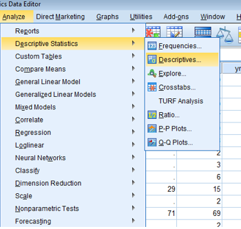

Belirtici istatistikleri hesaplanacak olan veriler ***Variables*** alanına taşınır.

[figure not shown]

Hangi istatistiklerin hesaplanacağını belirlemek için ***Options*** butonu tıklanır. SPSS’de hesaplanabilecek belirtici istatistikler ve dağılım istatistikleri aşağıdaki şekilde belirtilmiştir.

Seçimler yapıldıktan sonra Continue tıklanır ve ana ekrana dönülür.

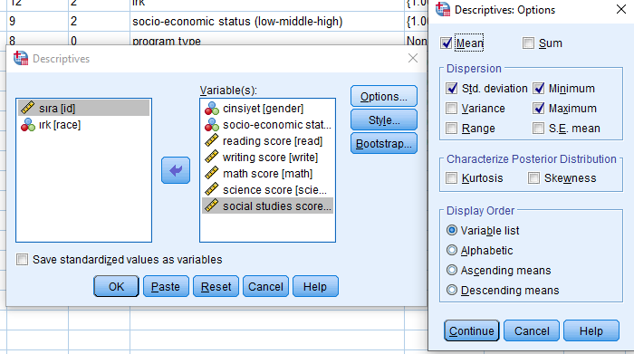

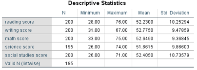

Descriptive statistics tablosunda ilk sütun değişkenleri gösterir. N ise toplam birim sayısını gösterir.

## 2. **Dağılım Ölçüleri**

Verileri dağılım biçimini, ortalama etrafında değişimini, yayılmalarını ve serpilmelerini belirlemeye yarayan ölçülerdir. Değişim ölçüleri ve açıklamaları aşağıda verilmiştir.

***Değişim Aralığı (Range, DA)***

- Bir dizide en büyük değer (Xmax) ile en küçük değer (Xmin) arasındaki farktır.

***Varyans (Variance)***

- Bir dizideki değerlerin ortalamadan olan farkları kareleri toplamının (n-1) sayısına bölünmesiyle bulunan bir dağılım ölçüsüdür.
- Kare farklarının ortalaması diye de isimlendirilir.

***Standart Sapma (Standart Deviation)***

- Varyansın karekökü alınarak bulunan bir standart dağılım ölçüsüdür.
- Birimi değişkenin ölçü birimine eşittir.

***Standart Hata (Standart Error of Mean)***

- Standart sapmanın birim sayısının kare köküne bölünmesiyle bulunan bir dağılım ölçüsüdür.
- Ölçü birimi değişkenin ölçü birimi ile aynıdır.

***Enbüyük Değer (Maximum, Xmax)***

- Bir dizideki gözlenen en büyük değerli gözlemdir.
- Xmax biçiminde gösterilir.

***Enküçük Değer (Minimum, Xmin)***

- Bir dizideki gözlenen en küçük değerli gözlemdir.
- Xmin biçiminde gösterilir.

***Değişim Katsayısı (Coefficient of Variation)***

- Bir dizinin standart sapmasının ortalamasına bölünmesi ve 100 ile çarpılması ile bulunan bir dağılım ölçüsüdür.
- Ölçü birimleri birbirinden farklı iki ya da daha fazla değişkenin dağılım yoğunluklarını karşılaştırmak amacıyla yararlanılan bir ölçüdür.
- Birimi yoktur.

***Çarpıklık (Skewness)***

- Bir dağılımın normal dağılıma göre simetrik ya da çarpık (asimetrik) olup olmadığını belirten bir ölçüdür. $α_3$ gösterilir.
- Simetrik (normal) dağılımda $α_3$ ‘ün değeri 0’dır.
- $α_3$ ’ün önemliliği, dağılımın simetrik olup olmadığı, normal dağılım yaklaşımıyla test edilir.

***Basıklık (Kurtosis)***

- Bir dağılımın normal dağılıma göre basık ya da sivri sivri (tepeleşmiş) olup olmadığını belirten bir ölçüdür.
- Basıklık ölçüsü normal dağılımda 3 değerini alır.
- Dağılımın basıklığının önemliliği, normal dağılıma göre basık olup olmadığı normal dağılım yaklaşımıyla test edilir.

### Dağılım Ölçülerinin Uygulaması

Menü yoluyla:

***Analyze > Descriptive Statistics > Descriptives*** seçenekleri tıklanır.

Değişkenler ***Variables*** tarafına koyulduktan sonra ***Options*** seçeneğinden ölçüler seçilir ve ***Continue*** seçeneği ile diyalog kutusu kapatılır.

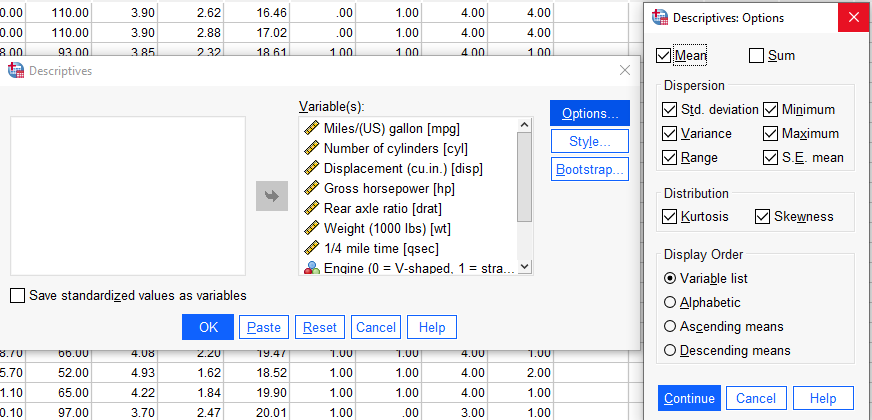

Daha sonra ***OK*** denilerek sonuçlar tablo halinde elde edilir.

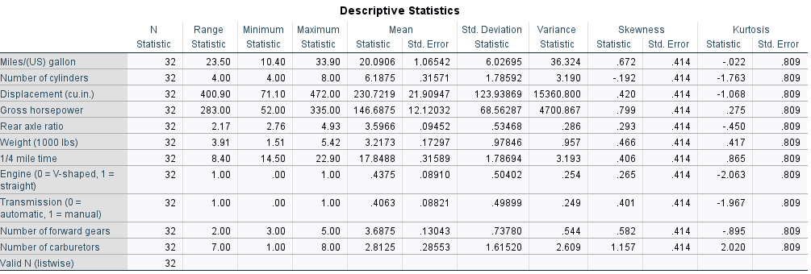

### Frekans Serisi Oluşturma

SPSS te tasnif edilmiş (frekanslı) seriyi oluşturmak için ***Analyze*** menüsünden ***Descriptive Statistics*** ve ***Frequencies*** tıklanır.

[figure not shown]

**Not:** Kullanılan değişkenler **mtcars (otomobiller)** verisetinin Türkçe ve İngilizce değişken isimleridir.

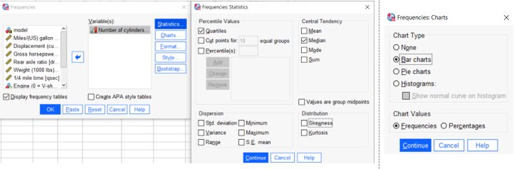

Silindir Sayısının dağılımı aşağıdaki şekilde çıktı ekranında görüntülenir.

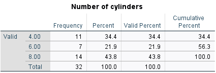

Dağılımın çubuk grafiği aşağıdaki şekilde görüntülenir.

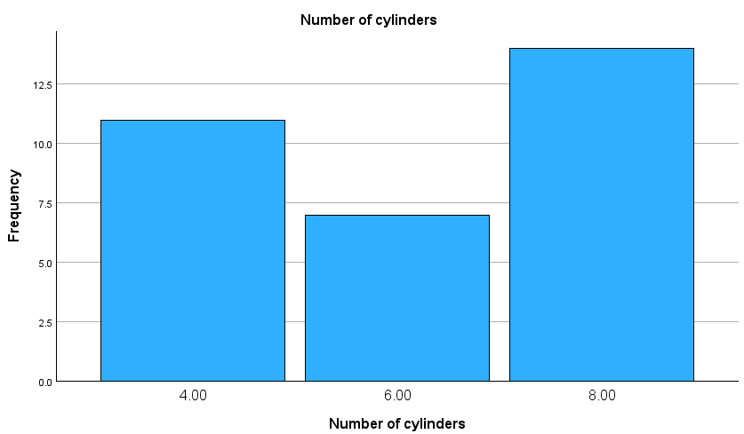

## Explore (Keşfetme) Seçeneği

Explore prosedürü, tüm vakalarınız için veya vaka grupları için ayrı ayrı özet istatistikler ve grafiksel görüntüler üretir. Araştırma prosedürünü kullanmanın birçok nedeni vardır:

- veri taraması,
- aykırı değerlerin belirlenmesi,
- açıklama,
- varsayım kontrolü ve alt popülasyonlar (vaka grupları) arasındaki farklılıkların karakterize edilmesi.

Veri taraması olağandışı değerlere, aşırı değerlere, verilerdeki boşluklara veya diğer özelliklere sahip olduğunuzu gösterebilir. Verileri araştırmak, veri analizi için düşündüğünüz istatistiksel tekniklerin uygun olup olmadığını belirlemenize yardımcı olabilir.

### Explore (Keşfetme) Seçeneği Uygulaması

Explore (Keşfetme) Seçeneği Uygulaması için **hs0.sav** datası kullanılmıştır.

SPSS'deki **Explore** işlevini kullanarak reading score (okuma skoru) için daha ayrıntılı özet istatistikler elde edebiliriz.

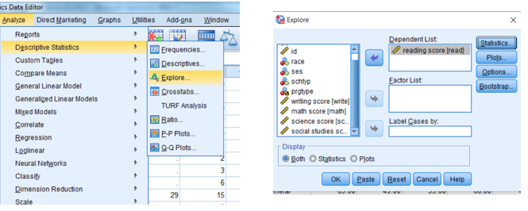

**Sonuçları**

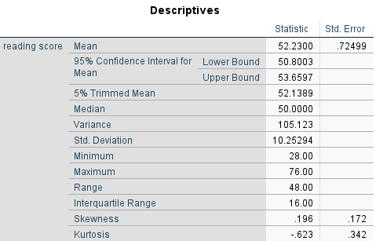

Daha detaylı bilgiler için (aşırı değerler: outliers, yüzdelikler: percentiles vb.) ***Statistics*** seçeneği seçilebilir.

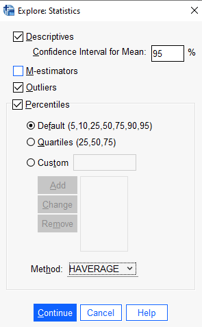

Daha detaylı grafiksel bilgiler için (histogram, steam-leaf diyagramı, boxplot) ***Plots*** seçeneği seçilebilir.

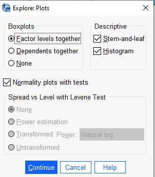

**Sonuçları**

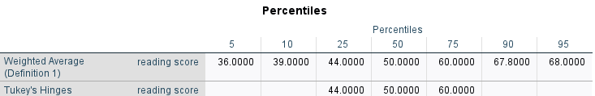

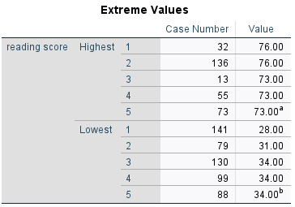

**Grafiksel Sonuçlar**

Histogram

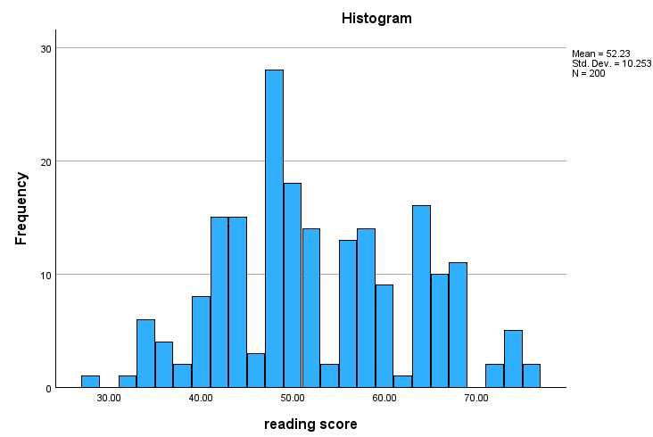

Stem-leaf diyagramı

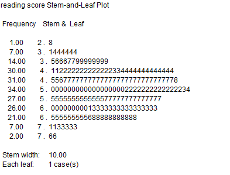

Boxplot

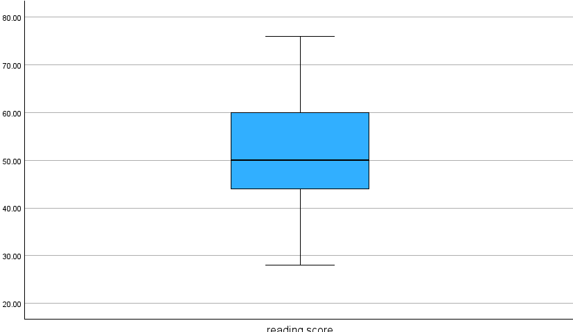

### Tabakalı Betimleyiciler (Stratified Descriptives) Uygulaması

Tabakalı Betimleyiciler için ***Split File*** Kullanımı

Değişik analizlerde kullanılmak üzere bir veri dosyasını alt gruplara böler, ayırır. Tablo içindeki değişkenleri belli değişkenlere göre gruplayıp her grubun ayrı ayrı istatistik değerlendirmesini yapabiliriz.

Menü yoluyla:

***Data > Split File***

[figure not shown]

***Ses (Sosyo Ekonomik Statü)*** değişkeni üzerinde veri bölümlemesini yapalım. Bu değişkenin 3 alt kategorisi (düşük, orta ve yüksek) vardır. Veriyi artık yapacağımız bütün işlemlerde bu 3 alt gruba ayrılmış olarak yapacağız.

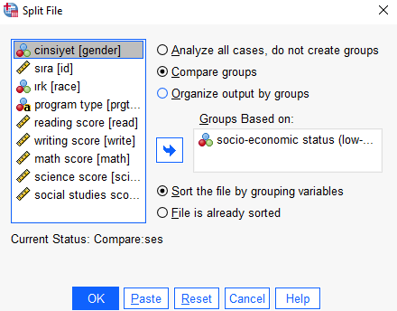

**Ses (Sosyo Ekonomik Statü)** değişkenini tabakalandırdıktan diğer değişkenlerinde özet istatistiklerini alalım.

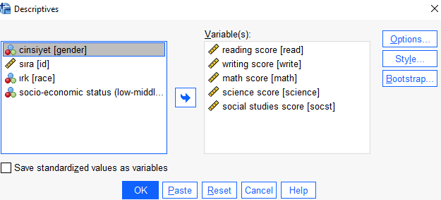

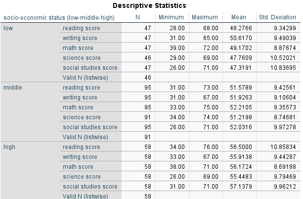

Daha sonra verimizi filtreleme işlemini yaptıktan sonra bir daha özet betimleyici istatistiklerine bakalım. Burada daha önce yaptığımız betimleyici istatistiklerinden farkı bu bilgileri 3 gruba ayırarak vermesidir.

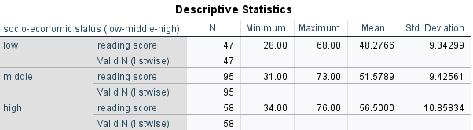

Tabakalı Betimleyiciler (Stratified Descriptives) ile verimiz bölümlendirildikten sonra bütün yapacağımız analizler bu filtrelemeye göre yapılacaktır. Bu filtreyi kaldırmak için aynı menüyü açıp **Analyze all cases, do not create groups** seçilip **OK** 'e tıklanması gerekir.

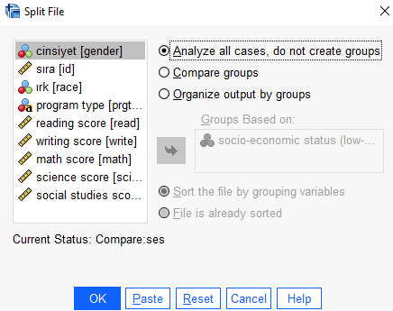